# Reproducible Research: Peer Assessment 1

# Reproducible Research: Course Project 1

**Read the file**

```r
# Download csv file from internet
rm(list = ls())
getwd()
```

```
## [1] "C:/Users/Deepak/Documents/John Hopkins Data science/Reproducible Research/Week 2"
```

```r
setwd("C:/Users/Deepak/Documents")
directory <- "John Hopkins Data science/Reproducible Research/Week 2"
url <- "https://d396qusza40orc.cloudfront.net/repdata%2Fdata%2Factivity.zip"
path <- paste(getwd(),directory,sep="/")
print(path)
```

```
## [1] "C:/Users/Deepak/Documents/John Hopkins Data science/Reproducible Research/Week 2"
```

```r
filename <- "activity.zip"
fullname <- paste(path,filename,sep="/")
fullname
```

```
## [1] "C:/Users/Deepak/Documents/John Hopkins Data science/Reproducible Research/Week 2/activity.zip"
```

```r
#download.file(url,destfile = fullname)
#dateDownloaded <- date()

## Unzip the files and save the list of files into data
actData <- unzip(fullname,list = TRUE)$Name
## actData

## Remove the variables not required from the workspace to clear the space
#rm(url)
#rm(path)
#rm(filename)
#rm(fullname)

## Rad the actData into R
actData <- read.csv(actData) #17568 obs. of 3 variables
str(actData)
```

```
## 'data.frame':    17568 obs. of  3 variables:
##  $ steps   : int  NA NA NA NA NA NA NA NA NA NA ...
##  $ date    : Factor w/ 61 levels "2012-10-01","2012-10-02",..: 1 1 1 1 1 1 1 1 1 1 ...
##  $ interval: int  0 5 10 15 20 25 30 35 40 45 ...
```

```r
head(actData)
```

```
##   steps       date interval
## 1    NA 2012-10-01        0
## 2    NA 2012-10-01        5
## 3    NA 2012-10-01       10
## 4    NA 2012-10-01       15
## 5    NA 2012-10-01       20
## 6    NA 2012-10-01       25
```

**Process/Transform the data (if necessary) into a format suitable for your analysis**

```r
library(plyr)

actData$date<-as.Date(actData$date)

actSum<-ddply(actData, "date", summarize, totalSteps=sum(steps,na.rm = TRUE))
head(actSum)
```

```
##         date totalSteps
## 1 2012-10-01          0
## 2 2012-10-02        126
## 3 2012-10-03      11352
## 4 2012-10-04      12116
## 5 2012-10-05      13294
## 6 2012-10-06      15420
```

```r
str(actSum)
```

```
## 'data.frame':    61 obs. of  2 variables:
##  $ date      : Date, format: "2012-10-01" "2012-10-02" ...
##  $ totalSteps: int  0 126 11352 12116 13294 15420 11015 0 12811 9900 ...
```

**Make a histogram of the total number of steps taken each day and save the plot as a png file**

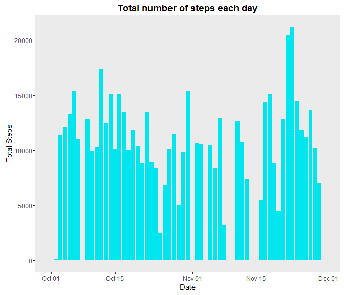

```r
## Make a histogram of the total number of steps taken each day
library(ggplot2)

#setwd(paste0(getwd(),directory))
meanPlot <- ggplot(actSum, aes(x=date, y=totalSteps))
meanPlot <- meanPlot + geom_bar(fill="#00E5EE", stat="identity")
meanPlot <- meanPlot + labs(x = "Date")
meanPlot <- meanPlot + labs(y = "Total Steps")
meanPlot <- meanPlot + labs(title="Total number of steps each day")
meanPlot <- meanPlot + theme(plot.title = element_text(lineheight=.8, face="bold"),panel.grid.major = element_blank()
                             ,panel.grid.minor = element_blank())
print(meanPlot)
```

```r
dev.copy(png, file = "Total Num of steps.png",height = 480, width = 480)
```

```r
dev.off()
```

```r
actMean <- mean(actSum$totalSteps)
```

```r
actMedian <- median(actSum$totalSteps)
```

**What is the average daily activity pattern?**

Make a time series plot (i.e. type = “l”) of the 5-minute interval (x-axis) and the average number of steps taken, averaged across all days (y-axis)

```r
## Create a line plot for the Daily activity pattern by interval

actInterval <- ddply(actData,"interval", summarize, avgSteps=mean(steps, na.rm=TRUE))
head(actInterval)
```

```
##   interval  avgSteps
## 1        0 1.7169811
## 2        5 0.3396226
## 3       10 0.1320755
## 4       15 0.1509434
## 5       20 0.0754717
## 6       25 2.0943396
```

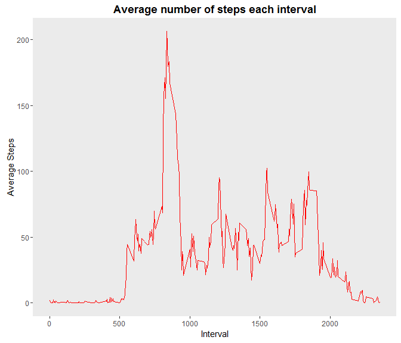

```r
intPlot <- ggplot(actInterval, aes(x=interval, y=avgSteps))
intPlot <- intPlot + geom_line(colour="red")
intPlot <- intPlot + labs(x = "Interval")
intPlot <- intPlot + labs(y = "Average Steps")
intPlot <- intPlot + labs(title="Average number of steps each interval")
intPlot <- intPlot + theme(plot.title = element_text(lineheight=.8, face="bold"),panel.grid.major = element_blank()
                             ,panel.grid.minor = element_blank())
print(intPlot)
```

```r
dev.copy(png, file = "Avg Num of steps per interval.png",height = 480, width = 480)
```

```r
dev.off()
```

**Which 5-minute interval, on average across all the days in the dataset, contains the maximum number of steps?**

```r
maxSteps <- actInterval[which.max(actInterval$avgSteps),1] #835th interval has the max avg
```

*On average, across all the days in the dataset, the maximum number of steps occurs during interval 835!*

**Imputing missing values**

Note that there are a number of days/intervals where there are missing values (coded as NA). The presence of missing days may introduce bias into some calculations or summaries of the data.

Calculate and report the total number of missing values in the dataset (i.e. the total number of rows with NAs)

```r
missingVal <- sum(is.na(actData$steps)) #2304
```

*There are 2304 NA values in the dataset.*

Devise a strategy for filling in all of the missing values in the dataset. The strategy does not need to be sophisticated. For example, you could use the mean/median for that day, or the mean for that 5-minute interval, etc.

*I employed a strategy where I impute the 5-minute interval mean.*

Create a new dataset that is equal to the original dataset but with the missing data filled in.

```r
actData2 <- actData
actInterval2 <- ddply(actData2,"interval", summarize, avgSteps=mean(steps, na.rm=TRUE))
head(actInterval2)
```

```
##   interval  avgSteps
## 1        0 1.7169811
## 2        5 0.3396226
## 3       10 0.1320755
## 4       15 0.1509434
## 5       20 0.0754717
## 6       25 2.0943396
```

```r
head(actData2)
```

```
##   steps       date interval
## 1    NA 2012-10-01        0
## 2    NA 2012-10-01        5
## 3    NA 2012-10-01       10
## 4    NA 2012-10-01       15
## 5    NA 2012-10-01       20
## 6    NA 2012-10-01       25
```

```r
for(i in 1:length(actData2$steps)){
    if(is.na(actData2[i,1])){
            print("Yes it matched")
            actData2[i,1] <- actInterval2[which(actInterval2$interval == actData2[i,3]),2]
    }
    else{
        actData2[i,1]<- actData2[i,1]
    }
}
```

[output not shown]

[output cut: 2289 more lines]

```r
head(actData2)
```

```
##       steps       date interval
## 1 1.7169811 2012-10-01        0
## 2 0.3396226 2012-10-01        5
## 3 0.1320755 2012-10-01       10
## 4 0.1509434 2012-10-01       15
## 5 0.0754717 2012-10-01       20
## 6 2.0943396 2012-10-01       25
```

```r
sum(is.na(actData2$steps))
```

```
## [1] 0
```

Make a histogram of the total number of steps taken each day and Calculate and report the mean and median total number of steps taken per day.

```r
actSum2<-ddply(actData2, "date", summarize, totalSteps=sum(steps))
actSum2$date <- as.Date(actSum2$date,format = "%Y-%m-%d")
head(actSum2)
```

```
##         date totalSteps
## 1 2012-10-01   10766.19
## 2 2012-10-02     126.00
## 3 2012-10-03   11352.00
## 4 2012-10-04   12116.00
## 5 2012-10-05   13294.00
## 6 2012-10-06   15420.00
```

```r
str(actSum2)
```

```
## 'data.frame':    61 obs. of  2 variables:
##  $ date      : Date, format: "2012-10-01" "2012-10-02" ...
##  $ totalSteps: num  10766 126 11352 12116 13294 ...
```

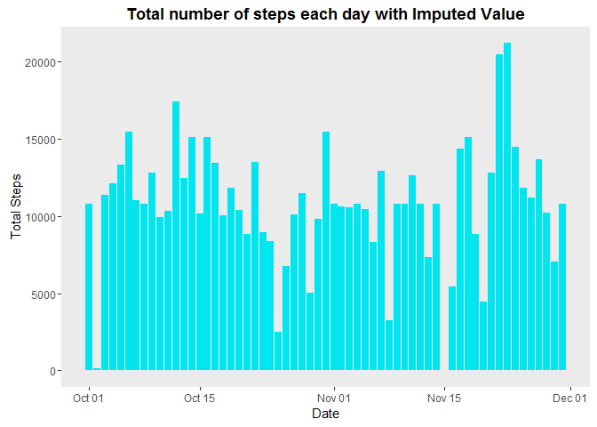

```r
meanPlot <- ggplot(actSum2, aes(x=date, y=totalSteps))
meanPlot <- meanPlot + geom_bar(fill="#00E5EE", stat="identity")
meanPlot <- meanPlot + labs(x = "Date")
meanPlot <- meanPlot + labs(y = "Total Steps")
meanPlot <- meanPlot + labs(title="Total number of steps each day with Imputed Value")
meanPlot <- meanPlot + theme(plot.title = element_text(lineheight=.8, face="bold"),panel.grid.major = element_blank()
                             ,panel.grid.minor = element_blank())
print(meanPlot)
```

```r
dev.copy(png, file = "Imputed mean histogram.png",height = 480, width = 480)
```

```r
dev.off()
```

```r
actMean2 <- mean(actData2$steps)
```

```r
actMedian2 <- median(actData2$steps)
```

Do these values differ from the estimates from the first part of the assignment? What is the impact of imputing missing data on the estimates of the total daily number of steps?

*This histogram is more centralizied, with more values landing on the average, whereas the tails are mostly not affected.*

**Are there differences in activity patterns between weekdays and weekends?**

For this part the weekdays() function may be of some help here. Use the dataset with the filled-in missing values for this part.

Create a new factor variable in the dataset with two levels – “weekday” and “weekend” indicating whether a given date is a weekday or weekend day.

```r
actData2$dayType <- ifelse(weekdays(as.Date(actData2$date)) %in% c("Saturday","Sunday"), "weekend", "weekday")
actData2$dayType <- as.factor(actData2$dayType)
levels(actData2$dayType)
```

```
## [1] "weekday" "weekend"
```

```r
intplot2 <- ddply(actData2,.(interval,dayType), summarize, avgSteps=mean(steps, na.rm=TRUE))
head(intplot2)
```

```
##   interval dayType   avgSteps
## 1        0 weekday 2.25115304
## 2        0 weekend 0.21462264
## 3        5 weekday 0.44528302
## 4        5 weekend 0.04245283
## 5       10 weekday 0.17316562
## 6       10 weekend 0.01650943
```

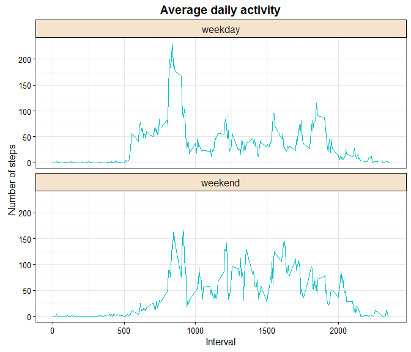

```r
intPlot <- ggplot(intplot2,
            aes(x=interval,
                y=avgSteps))
intPlot <- intPlot + theme_bw()
intPlot <- intPlot + geom_line(colour="#00BFC4")
intPlot <- intPlot + facet_wrap( ~ dayType, ncol=1)
intPlot <- intPlot + labs(x = "Interval")
intPlot <- intPlot + labs(y = "Number of steps")
intPlot <- intPlot + labs(title="Average daily activity")
intPlot <- intPlot + theme(plot.title = element_text(lineheight=.8, face="bold"),
               strip.text.x = element_text(size=12),
               strip.background = element_rect(colour="black",fill="#F6E3CE"))
print(intPlot)
```

```r
dev.copy(png, file = "Avg Num of steps per interval with Imputed values.png",height = 480, width = 480)
```

```r
dev.off()
```